# WineReviewAnalyze

## Github地址：[DM-Homwork](https://github.com/VicenTYC/DM-Homework1)

```python
# Import modules
import numpy as np
import pandas as pd
import seaborn as sns
import bokeh as bk
from bokeh.io import output_notebook, show
output_notebook()
%matplotlib inline
import matplotlib.pyplot as plt
```

#### 忽略无关警告

```python
# Ignore irrelevant warnings
import warnings
warnings.filterwarnings('ignore')
```

```python
# 设置整体绘图打印样式
%config InlineBackend.figure_format='retina'
sns.set()
plt.rcParams['figure.figsize'] = (10, 6)
plt.rcParams['axes.labelpad'] = 10
sns.set_style("darkgrid")
# sns.set_palette("Reds")
# sns.set_context("poster", font_scale=1.0)
```

# 1.引入和分析数据

### 首先分析Wine-Reviews数据集,分析winemag-data_first150k.csv CSV文件。 使用Pandas库中的`read_csv()`方法将CSV文件的内容加载到DataFrame()对象中。传入参数中设置DataFrame列的名称。

### Data Columns

1. country：The country that the wine is from
2. description
3. designation：The vineyard within the winery where the grapes that made the wine are from
4. points：The number of points WineEnthusiast rated the wine on a scale of 1-100 (though they say they only post reviews for wines that score >=80)
5. price：The cost for a bottle of the wine
6. province：The province or state that the wine is from
7. region_1：The wine growing area in a province or state (ie Napa)
8. region_2：Sometimes there are more specific regions specified within a wine growing area (ie Rutherford inside the Napa Valley), but this value can sometimes be blank
9. variety：The type of grapes used to make the wine (ie Pinot Noir)
10. winery：The winery that made the wine

```python
# 属性列表
column_names = ["index", "country", "description", "designation", "points", "price",
             "province", "region_1", "region_2", "variety", "winery"]
```

```python
# 从CSV文件中读取数据
WinerDF = pd.read_csv("F:/Data Mining/Wine Reviews/wine-reviews/winemag-data_first150k.csv", sep=",", header=1,
                        names = column_names, index_col=0)
```

### 使用`shape（）`查看数据集的元组数量(150929,10)

```python
WinerDF.shape
```

```
(150929, 10)
```

### 使用`info()`查看数据的属性

```python
WinerDF.info()
```

```
<class 'pandas.core.frame.DataFrame'>
Int64Index: 150929 entries, 1 to 150929
Data columns (total 10 columns):
 #   Column       Non-Null Count   Dtype
---  ------       --------------   -----
 0   country      150924 non-null  object
 1   description  150929 non-null  object
 2   designation  105194 non-null  object
 3   points       150929 non-null  int64
 4   price        137234 non-null  float64
 5   province     150924 non-null  object
 6   region_1     125869 non-null  object
 7   region_2     60952 non-null   object
 8   variety      150929 non-null  object
 9   winery       150929 non-null  object
dtypes: float64(1), int64(1), object(8)
memory usage: 12.7+ MB
```

## 针对标称属性，统计其频数

```python
#查看所有不相等的国家
unique_countries = WinerDF["country"].unique()
print("Total amount of unique countries: {}".format(len(unique_countries)))
print(unique_countries)
```

```
Total amount of unique countries: 49
['Spain' 'US' 'France' 'Italy' 'New Zealand' 'Bulgaria' 'Argentina'
 'Australia' 'Portugal' 'Israel' 'South Africa' 'Greece' 'Chile' 'Morocco'
 'Romania' 'Germany' 'Canada' 'Moldova' 'Hungary' 'Austria' 'Croatia'
 'Slovenia' nan 'India' 'Turkey' 'Macedonia' 'Lebanon' 'Serbia' 'Uruguay'
 'Switzerland' 'Albania' 'Bosnia and Herzegovina' 'Brazil' 'Cyprus'
 'Lithuania' 'Japan' 'China' 'South Korea' 'Ukraine' 'England' 'Mexico'
 'Georgia' 'Montenegro' 'Luxembourg' 'Slovakia' 'Czech Republic' 'Egypt'
 'Tunisia' 'US-France']
```

### 使用`value_counts()`可以很方便的统计出各标称属性的频数

```python
#查看所有国家的频数统计
review_totals_country = WinerDF["country"].value_counts()
print("Total amount of countries:{}".format(len(review_totals_country)))
print(review_totals_country)
```

```
Total amount of countries:48
US                        62396
Italy                     23478
France                    21098
Spain                      8268
Chile                      5816
Argentina                  5631
Portugal                   5322
Australia                  4957
New Zealand                3320
Austria                    3057
Germany                    2452
South Africa               2258
Greece                      884
Israel                      630
Hungary                     231
Canada                      196
Romania                     139
Slovenia                     94
Uruguay                      92
Croatia                      89
Bulgaria                     77
Moldova                      71
Mexico                       63
Turkey                       52
Georgia                      43
Lebanon                      37
Cyprus                       31
Brazil                       25
Macedonia                    16
Serbia                       14
Morocco                      12
England                       9
Luxembourg                    9
Lithuania                     8
India                         8
Czech Republic                6
Ukraine                       5
Switzerland                   4
South Korea                   4
Bosnia and Herzegovina        4
Slovakia                      3
Egypt                         3
China                         3
Tunisia                       2
Albania                       2
Montenegro                    2
Japan                         2
US-France                     1
Name: country, dtype: int64
```

#### 对比上面两组数据，发现国家存在为空（NAN）的情况，进而使不同国家数多1。

## 查看各个属性的空值（缺失值）的个数

```python
# 每列空值的数目:
WinerDF.isnull().sum()
```

```
country            5
description        0
designation    45735
points             0
price          13695
province           5
region_1       25060
region_2       89977
variety            0
winery             0
dtype: int64
```

### 使用`.describe()` 函数来检查其他标称属性的概括信息

- **`count`** 列属性值的总数
- **`unique`** 不同数据值的数量
- **`top`** 频数最大的属性值
- **`freq`** 最大频数属性值对应的频数（众数）

### 并画出直方图

```python
# country的概括性信息
WinerDF["country"].describe()
```

```
count     150924
unique        48
top           US
freq       62396
Name: country, dtype: object
```

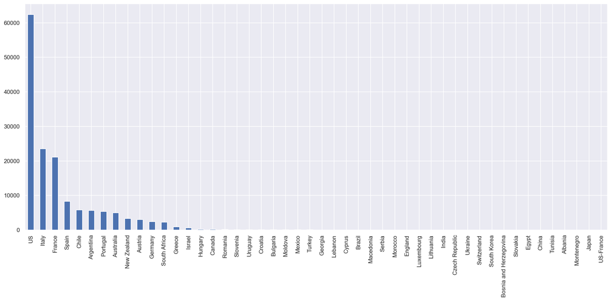

```python
# country的直方图
WinerDF["country"].value_counts().plot.bar()
```

```python
# designation的概括性信息
WinerDF["designation"].describe()
```

```
count      105194
unique      30621
top       Reserve
freq         2752
Name: designation, dtype: object
```

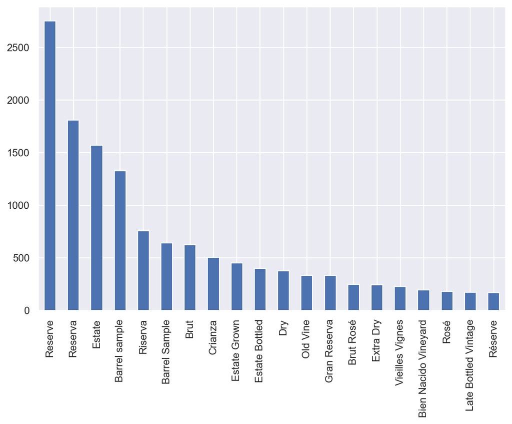

```python
# designation前20条频数统计数据的直方图
WinerDF["designation"].value_counts().head(20).plot.bar()
```

```python
# province的概括性信息
WinerDF["province"].describe()
```

```
count         150924
unique           455
top       California
freq           44507
Name: province, dtype: object
```

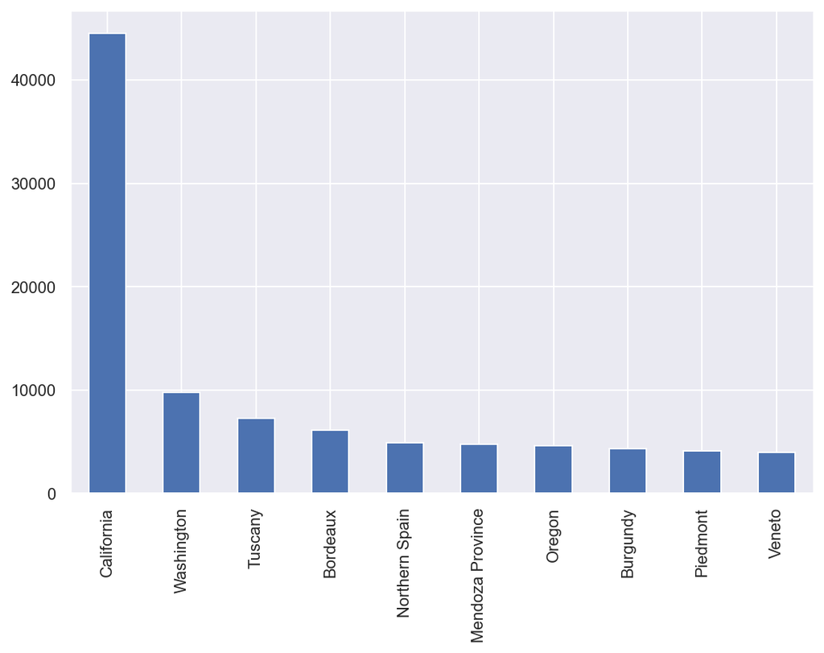

```python
# province前20条频数统计信息
WinerDF["province"].value_counts().head(10).plot.bar()
```

```python
# region_1的概括性信息
WinerDF["region_1"].describe()
```

```
count          125869
unique           1236
top       Napa Valley
freq             6208
Name: region_1, dtype: object
```

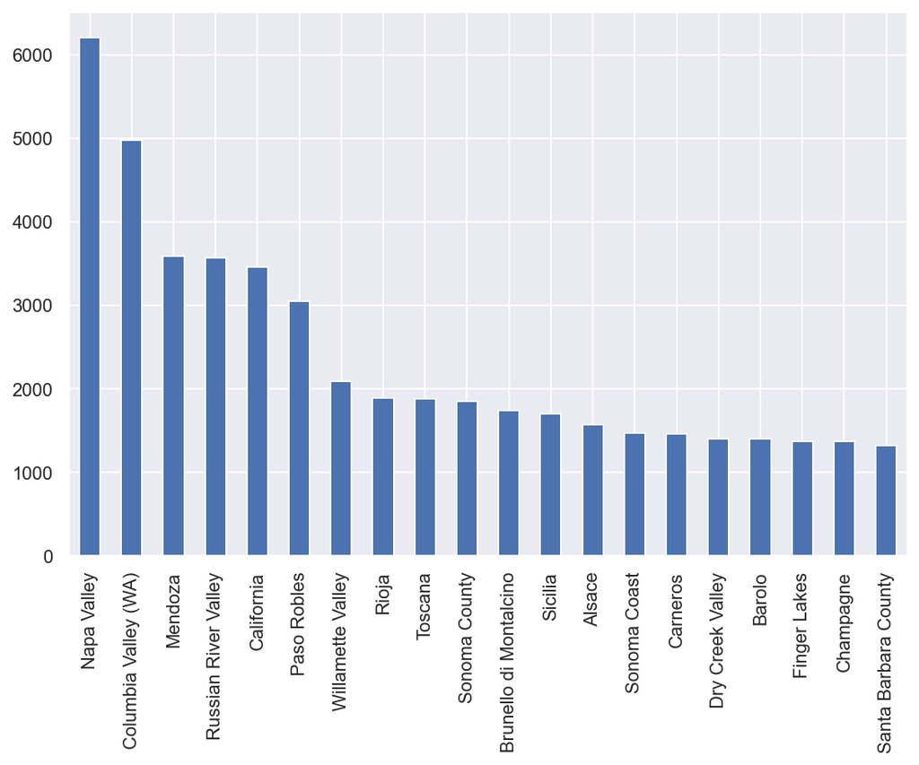

```python
# region_1前20条频数信息
WinerDF["region_1"].value_counts().head(20).plot.bar()
```

```python
# region_2的概括性信息
WinerDF["region_2"].describe()
```

```
count             60952
unique               18
top       Central Coast
freq              13057
Name: region_2, dtype: object
```

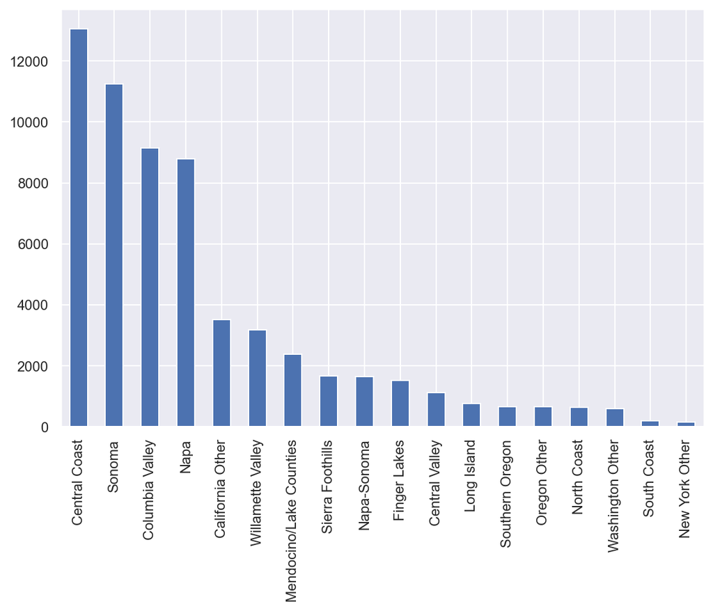

```python
# region_2对应的直方图
WinerDF["region_2"].value_counts().plot.bar()
```

```python
# variety的概括性信息
WinerDF["variety"].describe()
```

```
count         150929
unique           632
top       Chardonnay
freq           14482
Name: variety, dtype: object
```

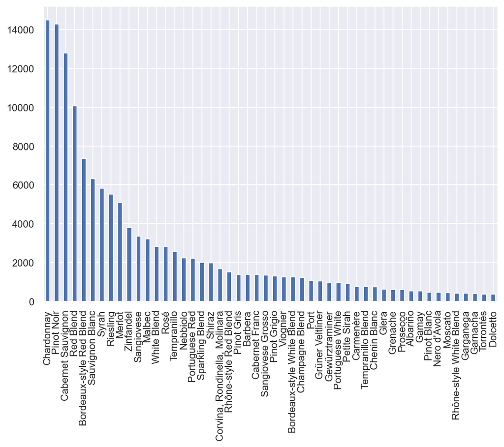

```python
# variety的前50条频数统计数据
WinerDF["variety"].value_counts().head(50).plot.bar()
```

```python
# winery的概括性信息
WinerDF["winery"].describe()
```

```
count              150929
unique              14810
top       Williams Selyem
freq                  374
Name: winery, dtype: object
```

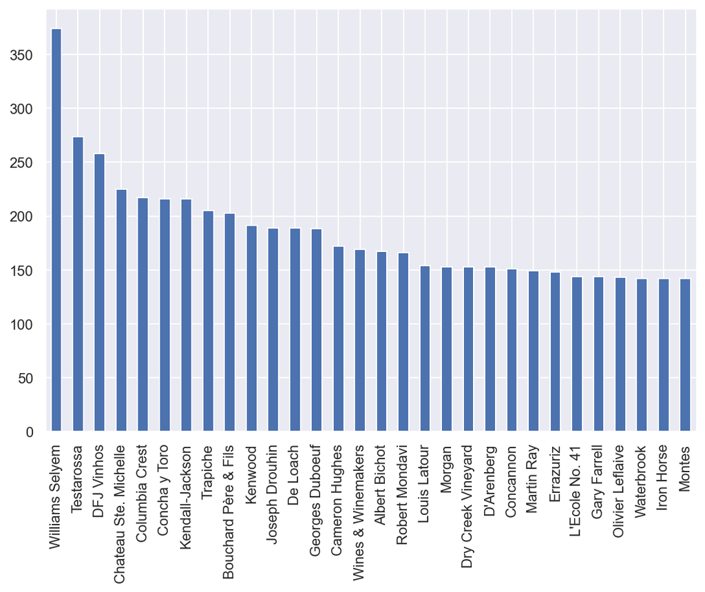

```python
WinerDF["winery"].value_counts().head(30).plot.bar()
```

### 对于`int`或者`float`类型的数值属性`describe()`可以方便的得到其五数概括

### 并使用`boxplot()`对指定列画出其箱型图

```python
WinerDF['points'].describe()
```

```
count    150929.000000
mean         87.888365
std           3.222335
min          80.000000
25%          86.000000
50%          88.000000
75%          90.000000
max         100.000000
Name: points, dtype: float64
```

#### points数据呈单峰分布, 且均值为87.88，中位数为88，众数为87

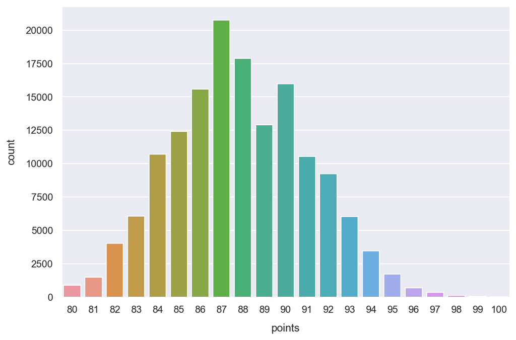

```python
sns.countplot(WinerDF['points'])
```

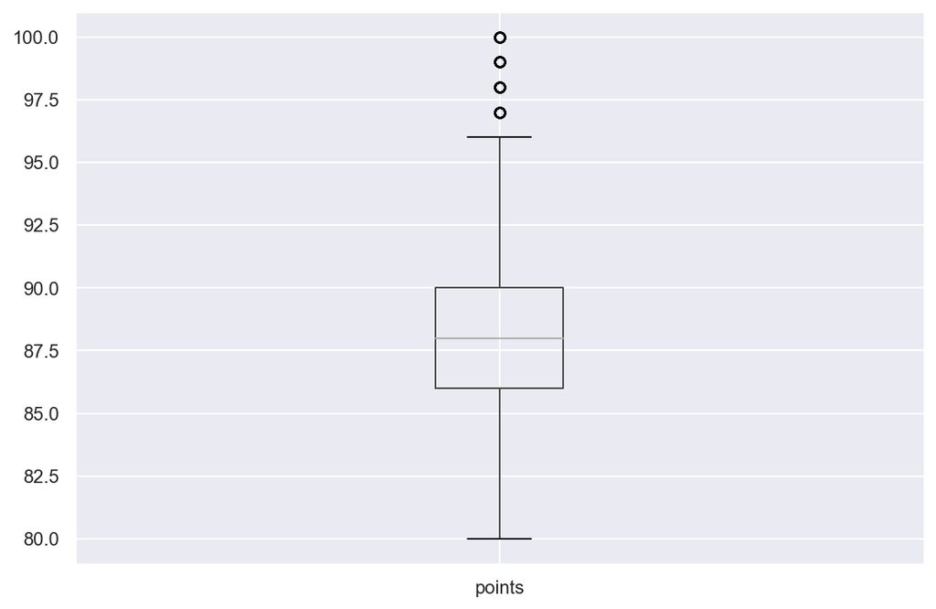

```python
# points的箱型图
WinerDF.boxplot(column='points')
```

```python
WinerDF['price'].describe()
```

```
count    137234.000000
mean         33.130012
std          36.318581
min           4.000000
25%          16.000000
50%          24.000000
75%          40.000000
max        2300.000000
Name: price, dtype: float64
```

#### 数据呈多峰分布，且均值为33.13，中位数为24，众数为20.0

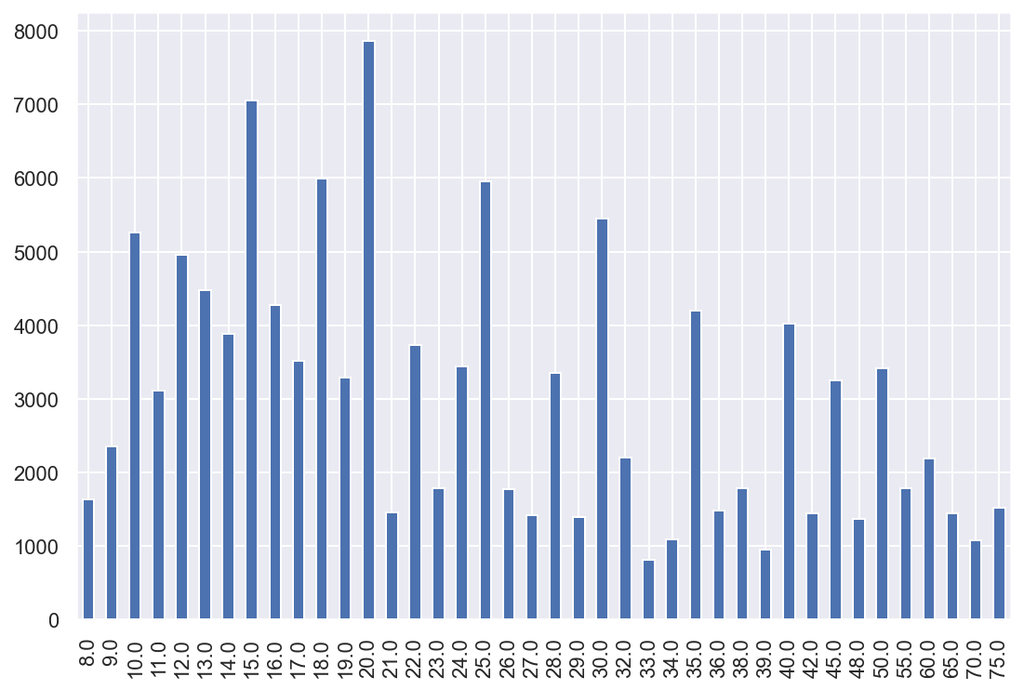

```python
 WinerDF['price'].value_counts().head(40).sort_index().plot.bar()
```

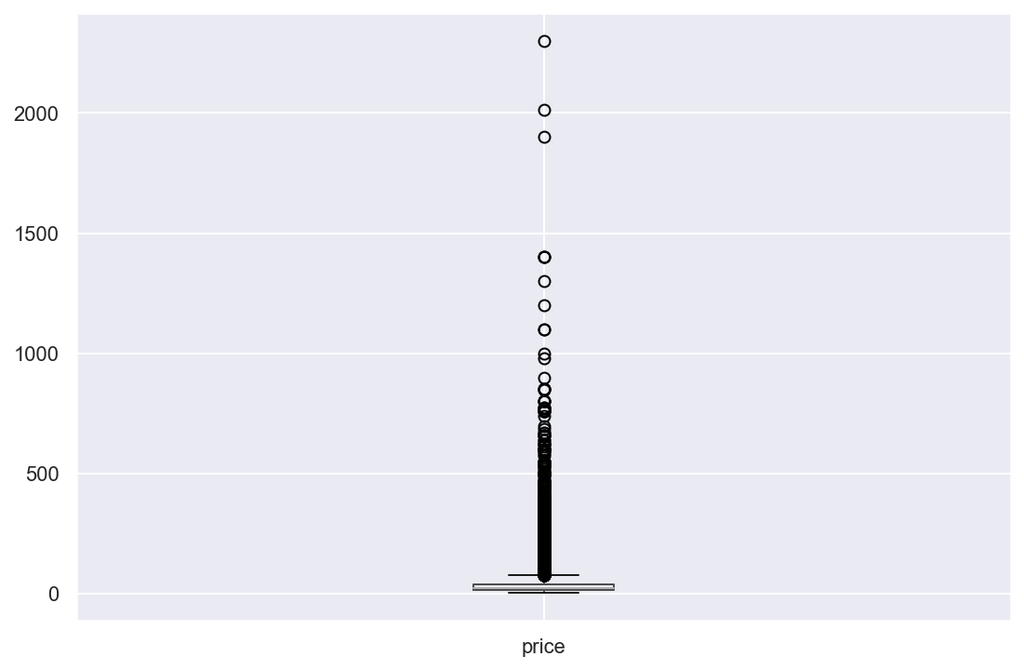

```python
WinerDF.boxplot(column='price')
```

## 接下来对缺失数据进行处理

### 进行简单线性拟合，使用points与price的相关性来填充price的缺值

```python
# 所有price为空的行构成待预测数据集
points_X = WinerDF[WinerDF.price.isnull()]['points']
points_X.head(3)
```

```
index
32    90
56    90
72    91
Name: points, dtype: int64
```

```python
# 计算 Spearman秩相关系数，判断相关性
from scipy.stats import spearmanr
import statsmodels.api as sm
from statsmodels.formula.api import ols

WinerDF_del = WinerDF.dropna(how="any", subset=["price"])
coef,p = spearmanr(WinerDF_del['points'], WinerDF_del['price'])
print('Spearmans 相关系数: %.4f' % coef)
alpha = 0.05
if p > alpha:
    print('样本不相关 (不能拒绝H0)')

else:
    print('样本相关 (r拒绝H0)')
```

```
Spearmans 相关系数: 0.5956
样本相关 (r拒绝H0)
```

```python
# 简单线性回归拟合
wine_model = ols("price ~points",data=WinerDF_del).fit()
print(wine_model.params)
price_pred = wine_model.predict(points_X)
# 使用预测值填充空值
for i in price_pred.keys():
    WinerDF[i-1:i]['price'] = price_pred[i]
```

```
Intercept   -421.941996
points         5.183769
dtype: float64
```

```python
WinerDF[WinerDF.price.isnull()]
```

|  | country | description | designation | points | price | province | region_1 | region_2 | variety | winery |
| --- | --- | --- | --- | --- | --- | --- | --- | --- | --- | --- |
| index |  |  |  |  |  |  |  |  |  |  |

### 对于“country”信息不允许为空，接着处理country属性

```python
# 查询country属性为空的行
WinerDF[WinerDF.country.isnull()]
```

| index | country | description | designation | points | price | province | region_1 | region_2 | variety | winery |
| --- | --- | --- | --- | --- | --- | --- | --- | --- | --- | --- |
| 1133 | NaN | Delicate white flowers and a spin of lemon pee... | Askitikos | 90 | 17.0 | NaN | NaN | NaN | Assyrtiko | Tsililis |
| 1440 | NaN | A blend of 60% Syrah, 30% Cabernet Sauvignon a... | Shah | 90 | 30.0 | NaN | NaN | NaN | Red Blend | Büyülübağ |
| 68226 | NaN | From first sniff to last, the nose never makes... | Piedra Feliz | 81 | 15.0 | NaN | NaN | NaN | Pinot Noir | Chilcas |
| 113016 | NaN | From first sniff to last, the nose never makes... | Piedra Feliz | 81 | 15.0 | NaN | NaN | NaN | Pinot Noir | Chilcas |
| 135696 | NaN | From first sniff to last, the nose never makes... | Piedra Feliz | 81 | 15.0 | NaN | NaN | NaN | Pinot Noir | Chilcas |

### 可以看到只有5条数据，数据量很小。并且对应其他可以推断国家的‘province’等属性也为空，

### 所以使用`dropna()`剔除这些行

```python
# t剔除空值元组
WinerDF = WinerDF.dropna(how="any", subset=["country"])
```

```python
# 查询country属性为空的行
WinerDF[WinerDF.country.isnull()]
```

|  | country | description | designation | points | price | province | region_1 | region_2 | variety | winery |
| --- | --- | --- | --- | --- | --- | --- | --- | --- | --- | --- |
| index |  |  |  |  |  |  |  |  |  |  |

### 使用最高频率值填充

```python
# 查看designation 空值
WinerDF[WinerDF.designation.isnull()].head(4)
```

| index | country | description | designation | points | price | province | region_1 | region_2 | variety | winery |
| --- | --- | --- | --- | --- | --- | --- | --- | --- | --- | --- |
| 36 | France | Gingery spice notes accent fresh pear and melo... | NaN | 90 | 60.0 | Rhône Valley | Châteauneuf-du-Pape | NaN | Rhône-style White Blend | Clos de L'Oratoire des Papes |
| 37 | Italy | Aromas of forest floor, violet, red berry and ... | NaN | 90 | 29.0 | Tuscany | Vino Nobile di Montepulciano | NaN | Sangiovese | Avignonesi |
| 38 | Italy | This has a charming nose that boasts rose, vio... | NaN | 90 | 23.0 | Tuscany | Chianti Classico | NaN | Sangiovese | Casina di Cornia |
| 48 | Italy | Ripe dark-skinned berry, forest floor and cook... | NaN | 90 | 50.0 | Tuscany | Brunello di Montalcino | NaN | Sangiovese | Brunelli Martoccia |

```python
# 使用最高频率值填充
designation_mode = WinerDF['designation'].value_counts().head(1).keys()[0]
WinerDF['designation'].fillna(designation_mode, inplace=True)
```

```python
# 查看designation 空值
WinerDF[WinerDF.designation.isnull()]
```

|  | country | description | designation | points | price | province | region_1 | region_2 | variety | winery |
| --- | --- | --- | --- | --- | --- | --- | --- | --- | --- | --- |
| index |  |  |  |  |  |  |  |  |  |  |

### 使用数据对象相似性填充

```python
#  由于之前删除数据，首先重置索引
WinerDF.reset_index(inplace=True,drop=True)

# 选择region_1 为空的元组
region_null = WinerDF[ WinerDF.region_1.isnull()][['province','variety','country']]
region_null
```

|  | province | variety | country |
| --- | --- | --- | --- |
| 24 | Kumeu | Chardonnay | New Zealand |
| 29 | Bulgaria | Mavrud | Bulgaria |
| 41 | Idaho | Petite Sirah | US |
| 63 | Alentejano | Portuguese Red | Portugal |
| 73 | Alentejo | Portuguese Red | Portugal |
| ... | ... | ... | ... |
| 150895 | Maipo Valley | Merlot | Chile |
| 150896 | Maipo Valley | Chardonnay | Chile |
| 150897 | Rapel Valley | Cabernet Sauvignon | Chile |
| 150898 | Maipo Valley | Cabernet Sauvignon | Chile |
| 150899 | Maipo Valley | Merlot | Chile |

25055 rows × 3 columns

### 当省份（州）和酿造葡萄酒的葡萄种类相同时，认为region_1值最有可能相同，用以填充当前元组。当找不到时，放宽范围使用同一省份（州）中最大频数的region_1来填充。最后对于找不到相似元组的数据，使用该国最大频数对应的值填充。 剩余的未能填充值元组，表明无法从现有数据获得有用的信息来填充。

```python
# 相似值填充
region = ''
ConProvDict={}
for row in region_null.itertuples():
    # 初始化
    if len(ConProvDict) ==0:
        simTuple = WinerDF[(WinerDF.province==row[1])& (WinerDF.variety==row[2]) & ~(WinerDF.region_1.isnull())]['region_1']
        if len(simTuple)==0:
            simTuple = WinerDF[(WinerDF.province==row[1])& ~(WinerDF.region_1.isnull())]['region_1']

        # 对于找不到相似元组的数据，使用该国region_1最大频数值填充
        if len(simTuple) ==0:
            simTuple = WinerDF[(WinerDF.country==row[3])& ~(WinerDF.region_1.isnull())]['region_1']
        if len(simTuple)==0:
            region = ''
            subDict = {row[2]:region}
            ConProvDict[row[1]]= subDict
        else:
            region = simTuple.value_counts().keys()[0]
            subDict = {row[2]:region}
            ConProvDict[row[1]]= subDict
            WinerDF[row[0]:row[0]+1]['region_1']= region
    if ConProvDict.get(row[1])!=None and ConProvDict[row[1]].get(row[2])!=None:
        region = ConProvDict[row[1]][row[2]]
        if region !='':
             WinerDF[row[0]:row[0]+1]['region_1']= region
    else:
        simTuple = WinerDF[(WinerDF.province==row[1])& (WinerDF.variety==row[2]) & ~(WinerDF.region_1.isnull())]['region_1']
        if len(simTuple)==0:
            simTuple = WinerDF[(WinerDF.province==row[1])& ~(WinerDF.region_1.isnull())]['region_1']
        # 对于找不到相似元组的数据，使用该国region_1最大频数值填充
        if len(simTuple) ==0:
            simTuple = WinerDF[(WinerDF.country==row[3])& ~(WinerDF.region_1.isnull())]['region_1']
        if len(simTuple)==0:
            region = ''
            subDict = {row[2]:region}
            ConProvDict[row[1]]= subDict
        else:
            region = simTuple.value_counts().keys()[0]
            subDict = {row[2]:region}
            ConProvDict[row[1]]= subDict
            WinerDF[row[0]:row[0]+1]['region_1']= region
```

```python
# 剩余region_1 为空的元组数
len(WinerDF[ WinerDF.region_1.isnull()])
```

```
24900
```

## 比较清洗前后的数据集

```python
# 获取原数据集，并删除country值为空的元组来对齐两个数据集
WinerDF_old = pd.read_csv("F:/Data Mining/Wine Reviews/wine-reviews/winemag-data_first150k.csv", sep=",", header=1,
                        names = column_names, index_col=0)
WinerDF_old = WinerDF_old.dropna(how="any", subset=["country"])
```

```python
price_now = WinerDF['price'].value_counts().head(357)
price_old = WinerDF_old['price'].value_counts().head(357)
newDF = pd.DataFrame({'price':price_now.values,'price_old':price_old.values})
newDF
```

|  | price | price_old |
| --- | --- | --- |
| 0 | 7860 | 7860 |
| 1 | 7053 | 7053 |
| 2 | 5988 | 5988 |
| 3 | 5955 | 5955 |
| 4 | 5448 | 5448 |
| ... | ... | ... |
| 352 | 1 | 1 |
| 353 | 1 | 1 |
| 354 | 1 | 1 |
| 355 | 1 | 1 |
| 356 | 1 | 1 |

357 rows × 2 columns

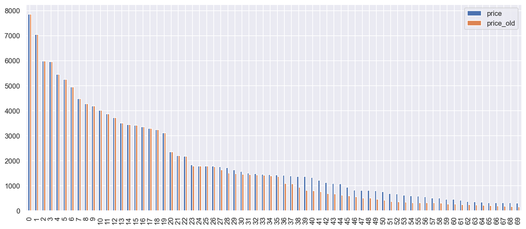

```python
plt.rcParams['figure.figsize'] = (14, 6)
newDF.sort_index().head(70).plot.bar()
```

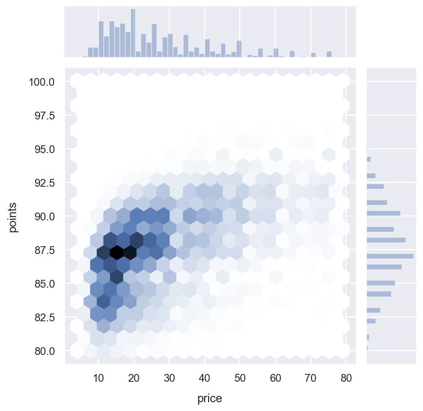

```python
# 原数据point-price蜂窝图
sns.jointplot(x='price', y='points', data=WinerDF_old[(WinerDF_old['price'] < 80) & (WinerDF['price']>0)], kind='hex',
              gridsize=20)
```

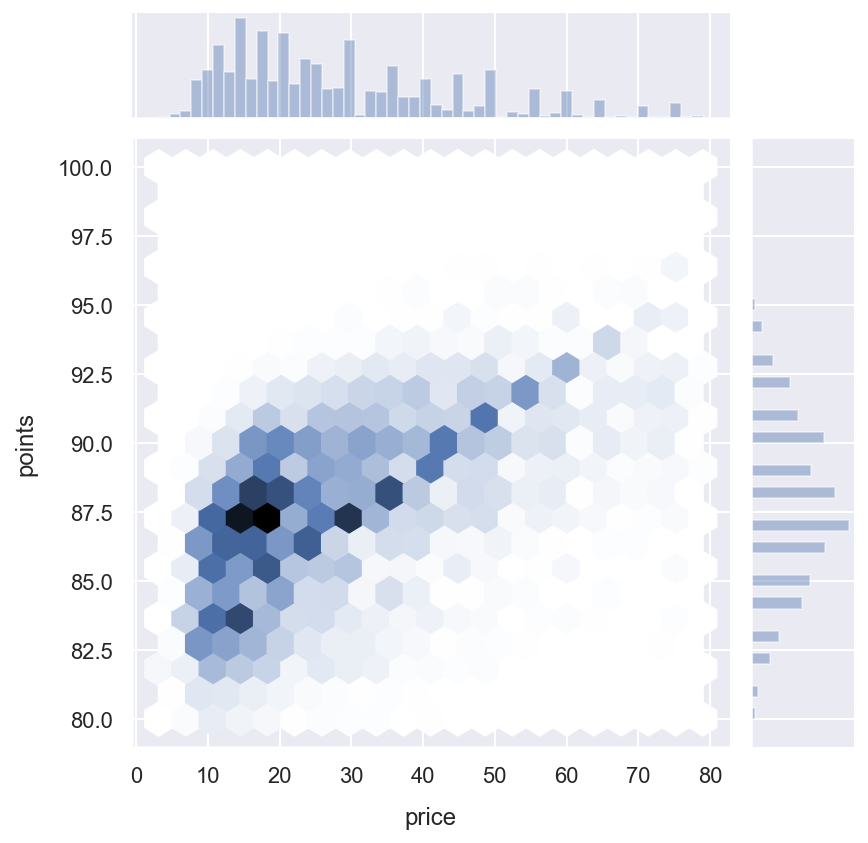

```python
# 清洗后数据point-price蜂窝图
sns.jointplot(x='price', y='points', data=WinerDF[(WinerDF['price'] < 80) & (WinerDF['price']>0)], kind='hex',
              gridsize=20)
```

### 比较数据清洗前后的蜂窝图，可以清楚的看到清洗后的point和price密度发生了显著的变化，原数据集密度集中在价格在10-20之间，而经过数据清洗，对缺失的价格数据补充后，发现数据在其他的区间力图20-30也发生了聚集，可能对数据分析产生影响。

# 接下来处理winemag-data-130k-v2.csv文件

```python
# 属性列表
column_names = ["index", "country", "description", "designation", "points", "price",
             "province", "region_1", "region_2","taster_name","taster_twitter_handle","title","variety", "winery"]
# 获取v2数据集
WinerDFV2 = pd.read_csv("F:/Data Mining/Wine Reviews/wine-reviews/winemag-data-130k-v2.csv", sep=",", header=1,
                        names = column_names, index_col=0)
```

### 对于其他属性的处理与第一个数据集大致相同，这里重点处理`region_1`属性的缺失值，region_2属性可能为空所以不做处理

### 通过观察可以得出，title属性值中括号里的内容通常为region_1的属性值，因此可以提取该值进行空值填充

```python
import re
comDF = WinerDFV2[~WinerDFV2['title'].isnull() & ~WinerDFV2['region_1'].isnull()][['title','region_1']]
comDFLen = len(comDF)
print("Data size:{}",comDFLen)
discom = comDF.apply( lambda x: 0 if re.search(r'[(](.*?)[)]',x['title'])==None else 1, axis=1).value_counts()
print(str(discom.keys()[1])+" (title提取不到region_1值), 数量为: "+str(discom.values[1]))
```

```
Data size:{} 108723
0 (title提取不到region_1值), 数量为: 10110
```

```python
comDF.apply( lambda x: x['title'] if re.search(r'[(](.*?)[)]',x['title'])==None else -1, axis=1).value_counts()
```

```
-1                                                    98613
Château Lestage Simon 2012  Haut-Médoc                    4
Domaine Vacheron 2015  Sancerre                           4
Château Arnaud 2011  Saint-Estèphe                        3
Château de Santenay 2012  Mercurey                        3
                                                      ...
Mauro Veglio 2010  Barbera d'Alba                         1
Molino di Sant'Antimo 2005  Brunello di Montalcino        1
Château de Riberon 2011  Bordeaux Supérieur               1
Château Timberlay 2014  Bordeaux Clairet                  1
Corte Adami 2012  Soave                                   1
Length: 9102, dtype: int64
```

### 可以看到title中确实不含region_1的信息，即不含括号

### 接下来统计在含有括号的title中提取到的region_1的值，与实际提供的region_1值相等的数量. 0代表不相等，1代表相等，-1代表提取不到信息

```python
# 统计相等数量
comDF.apply( lambda x: -1 if re.search(r'[(](.*?)[)]',x['title'])==None else (1 if re.search(r'[(](.*?)[)]',x[0]).group().replace('(','').replace(')','')== x['region_1'] else 0), axis=1).value_counts()
```

```
 1    92897
-1    10110
 0     5716
dtype: int64
```

### 所以可以认为，title中提取到的region_1有94.2%概率是正确的

### 接下来使用title中提取的信息填充region_1的缺失值。提取不到信息，使用province填充。

```python
WinerDFV2.reset_index(inplace=True,drop=True)
WinerDFV2New = WinerDFV2
NoneRegionList = WinerDFV2New[WinerDFV2New['region_1'].isnull()][['region_1','title','province']]
print( len(NoneRegionList))
for row in NoneRegionList.itertuples():
    if row[2]!=None:
        result =re.search(r'[(](.*?)[)]',row[2])
        if result !=None:
            region = result.group().replace('(','').replace(')','')
            WinerDFV2New[row[0]:row[0]+1]['region_1'] = region
```

```
21247
```

```python
# 查看补全之后的空值数量
len(WinerDFV2New[WinerDFV2New['region_1'].isnull()])
```

```
412
```

### 可以看到通过该步骤解决了 21247- 412 = 20835 条元组的region_1的值缺失

### 对比清洗前后的数据集

```python
# 获取原数据集
WinerDFV2Old = pd.read_csv("F:/Data Mining/Wine Reviews/wine-reviews/winemag-data-130k-v2.csv", sep=",", header=1,
                        names = column_names, index_col=0)
```

```python
region_now = WinerDFV2New['region_1']
region_old = WinerDFV2Old['region_1']
regionNowDF = pd.DataFrame({'region':region_now.values})
regionOldDF = pd.DataFrame({'region_old':region_old.values})

# 按列组成新的Dataframe
newDF2 = pd.concat( [ regionNowDF, regionOldDF] , axis=1 )
newDF2
```

|  | region | region_old |
| --- | --- | --- |
| 0 | Douro | NaN |
| 1 | Willamette Valley | Willamette Valley |
| 2 | Lake Michigan Shore | Lake Michigan Shore |
| 3 | Willamette Valley | Willamette Valley |
| 4 | Navarra | Navarra |
| ... | ... | ... |
| 129965 | Erben Müller-Burggraef | NaN |
| 129966 | Oregon | Oregon |
| 129967 | Alsace | Alsace |
| 129968 | Alsace | Alsace |
| 129969 | Alsace | Alsace |

129970 rows × 2 columns

### 接下来使用分组函数`groupby`，按处理后的region_1进行分组，并对分组结果进行聚和，size代表处理后该组 region_1 个数，count代表清洗前该组region_1的个数

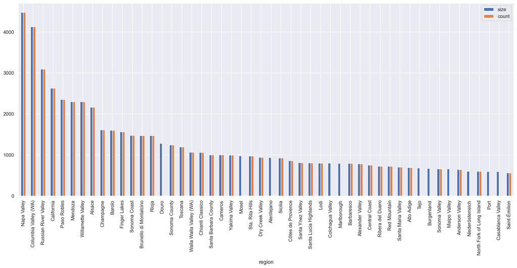

```python
# 调整直方图的尺寸
plt.rcParams['figure.figsize'] = (20, 8)
newDF2.groupby('region')['region_old'].agg(['size','count']).sort_values(by="size" , ascending=False).head(50).plot.bar()
```

### 可以明显看到通过处理补充了一些region_1类，获取到了新的信息